# Plotting in RStudio

Thomas Scofield

Feb. 17, 2020

## Using RMarkdown

For what follows I will use several data sets, including

- Student survey data from STAT 143 students at Calvin
- Data on eruptions of Old Faithful, found in *faithful*
- Data on iris plants, found in *iris*

The iris and faithful sets are built into R, but I’ve got to read in the student survey data.

```r
ss <- read.csv("http://scofield.site/teaching/data/csv/ssurv.csv")
```

Let’s look at this data.

```r
head(ss)
```

```
##   gender class gpa height pulse childrank numchildren haircut randomnum
## 1      F    So 3.6     NA    NA         2           3    2.00         6
## 2      F    So 3.4     NA    NA         4           4   10.00         7
## 3      M    Fr 3.0     71    68         2           4    0.00        17
## 4      M    So 2.6     72   100         2           1   15.00         3
## 5      M    So 2.2     68   101         4           3   11.00        13
## 6      M    So 2.4     72    74         2           2    9.99        11
##   speedtickets cds smoker hourssleep selfhandedness momhandedness dadhandedness
## 1            0  15    Non        8.0              R             L             R
## 2            0  10    Non        8.0              R             R             R
## 3            2  53    Non        5.5              R             R             R
## 4            3 170  Smoke        7.0              L             R             R
## 5            0  55  Smoke        8.0              R             R             R
## 6            0 101    Non        6.0              R             R             R
##     region oncampus cupscoffee birthday overtwenty
## 1 Suburban        Y          1       Th          Y
## 2    Rural        Y          0       Fr          N
## 3 Suburban        Y          0       Th          N
## 4 Suburban        Y          2       We          Y
## 5 Suburban        Y          0       Mo          N
## 6 Suburban        Y          0       Th          N
```

```r
names(ss)
```

```
##  [1] "gender"         "class"          "gpa"            "height"
##  [5] "pulse"          "childrank"      "numchildren"    "haircut"
##  [9] "randomnum"      "speedtickets"   "cds"            "smoker"
## [13] "hourssleep"     "selfhandedness" "momhandedness"  "dadhandedness"
## [17] "region"         "oncampus"       "cupscoffee"     "birthday"
## [21] "overtwenty"
```

### Univariate categorical data

We might be curious about the selfhandedness, a categorical variable. A frequency table, or a bar graph, can summarize its results.

```r
tally(~selfhandedness, data=ss)
```

```
## selfhandedness
##       L   R
##   1  31 248
```

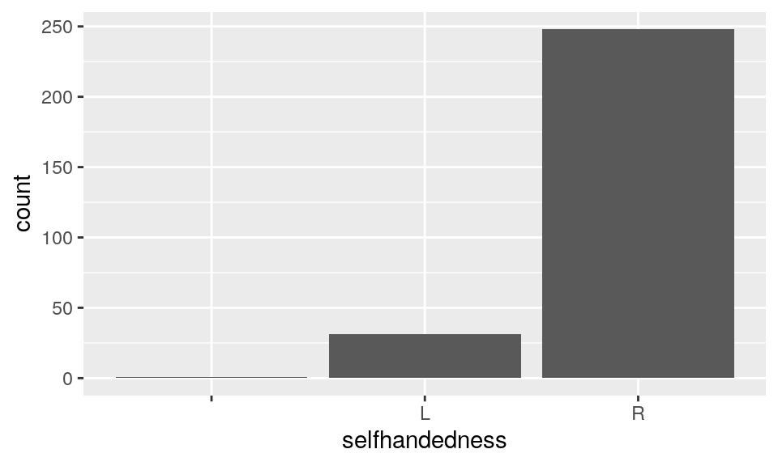

```r
gf_bar(~selfhandedness, data=ss)
```

Evidently, there is one survey respondent who neglected to share selfhandedness information.

Other common ways to view univariate categorical data include

- relative frequency table
- relative frequency bar chart
- pie chart (not recommended)

### Univariate quantitative data

One quantitative variable in the survey data is gpa. We have seen how favstats() offers us summary information.

```r
favstats(~gpa, data=ss)
```

```
##  min Q1 median  Q3 max     mean        sd   n missing
##  1.3  3    3.3 3.6   4 3.251267 0.4688413 273       7
```

It is possible to use tally to produce a frequency table for values of gpa, but there are so many different values reported, that may result in visual overload. (Go ahead. Try it.)

A more common way to plot quantitative is using a histogram.

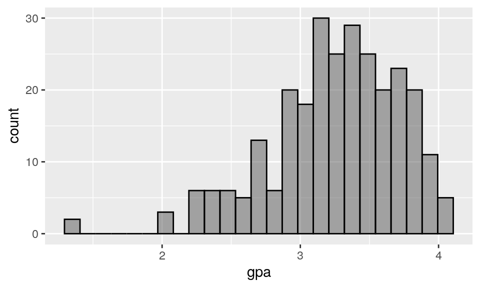

```r
gf_histogram(~gpa, data=ss, color="black")
```

Other common ways to view univariate quantitative data include

- dotplot (best when data set is small)
- boxplot (visual display of 5-number summary)

## Exploring associations between two variables

```r
tally(~selfhandedness | dadhandedness, data=ss)
```

```
##               dadhandedness
## selfhandedness       L   R
##                  1   0   0
##              L   0   5  26
##              R   2  23 223
```

Data often contains flaws, and the flaw this table reveals is that some student failed to supply a value for the selfhandedness variable, and three students did not supply dadhandedness. It seems likely their responses to these variables are the empty string "". We can use the filter() command to pull just the cases that we want, fitting one or more criteria we specify. The command

```r
filter(ss, selfhandedness != "")
```

calls for the cases in the ss data frame whose selfhandedness variable have a value different than the empty string. We might prefer to filter simultaneously grab only cases with nonempty answers in both selfhandedness and dadhandedness, with the command

```r
filter(ss, selfhandedness != "", dadhandedness != "")
```

If we make this, not the full ss data frame, the data from which our contingency table is built, we will get (mostly) what we want:

```r
tally(~selfhandedness | dadhandedness,
      data=filter(ss, selfhandedness!="",
                  dadhandedness!=""))
```

```
##               dadhandedness
## selfhandedness       L   R
##                  0   0   0
##              L   0   5  26
##              R   0  23 223
```

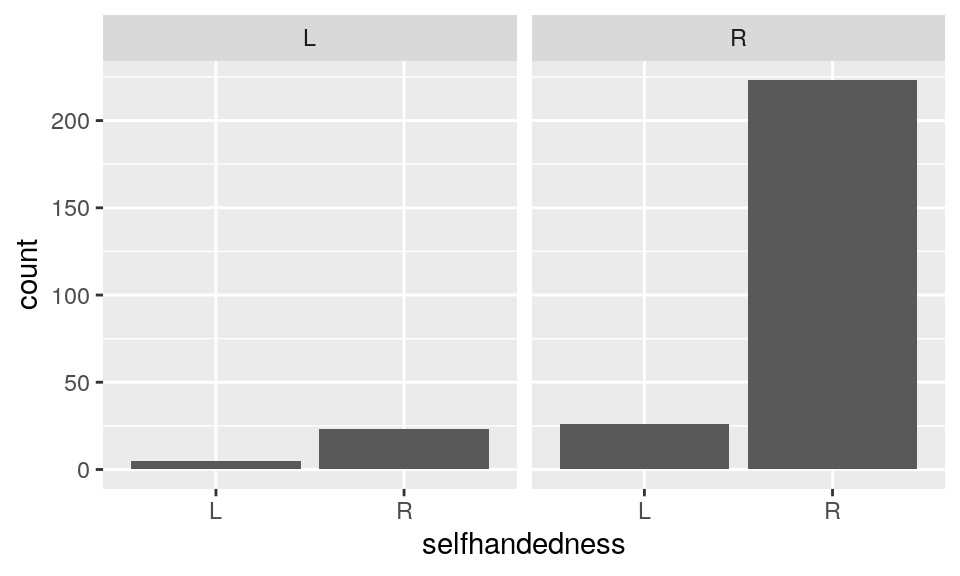

```r
gf_bar(~selfhandedness | dadhandedness,
      data=filter(ss, selfhandedness!="",
                  dadhandedness!=""))
```

```r
tally(~selfhandedness | dadhandedness, data=filter(ss,selfhandedness!="", dadhandedness!=""), format="proportion")
```

```
##               dadhandedness
## selfhandedness          L         R
##                 0.0000000 0.0000000
##              L  0.1785714 0.1044177
##              R  0.8214286 0.8955823
```

We do not see, as we might if there were no association, the same proportion of left-handed people with left-handed fathers as we see among those with right-handed fathers. But would they have to come out equal every time? Is the discrepancy, about 18% of those with left-handed fathers being left-handed, as opposed to only about 10% of those with right-handed fathers, due to more than sampling error?

### A categorical variable and a quantitative one

Is there a difference in Sepal.Width for the various species of iris plants? Species is a categorical variable, and we are likley treating it as a (possible) explanatory variable in an association with Sepal.Width. We might look at side-by-side histograms:

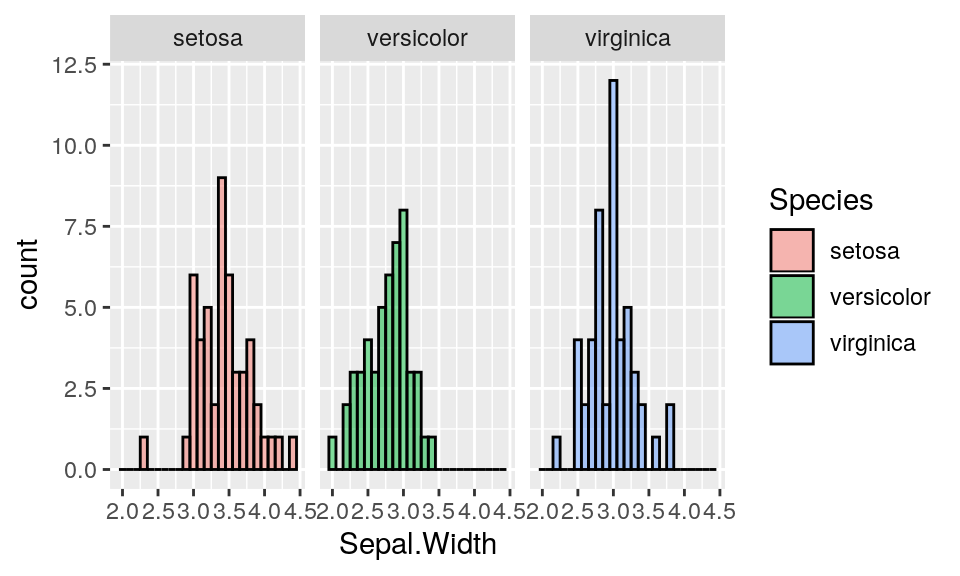

```r
gf_histogram(~Sepal.Width | Species, fill=~Species, data=iris, color="black")
```

Another option which can be visually appealing is side-by-side boxplots.

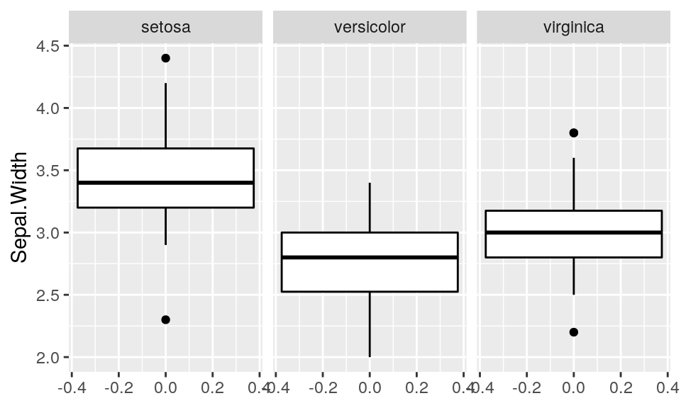

```r
gf_boxplot(~Sepal.Width | Species, data=iris, color="black")
```

Do you see indications here of an association"

### Two quantitative variables

Let’s take a quick look at the faithful dataset.

```r
head(faithful)
```

```
##   eruptions waiting
## 1     3.600      79
## 2     1.800      54
## 3     3.333      74
## 4     2.283      62
## 5     4.533      85
## 6     2.883      55
```

It contains two variables, both quantitative, namely eruptions and waiting. The cases are instances of the geyser known as Old Faithful spouting its froth in Yellowstone National Park. You can learn more with

```r
help(faithful)
```

The way to explore an association between quantitative variables is to use a **scatterplot**, obtained using the gf_point() command. It’s not clear which variable to take as explanatory. In the command below, I make eruptions explanatory (it comes after the tilde, and appears along the horizontal axis).

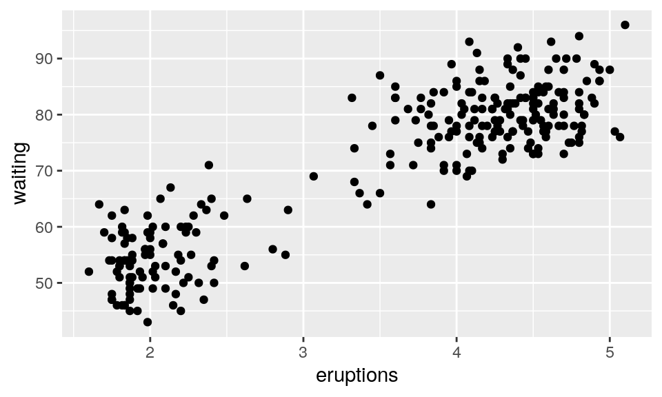

```r
gf_point(waiting~eruptions, data=faithful)
```

Do you see evidence of an association?